# TP FINAL

Juanjo Luna

2022-11-11

# **ANÁLISIS DE DATOS EN SALTA**

#### **CENTROS DEPORTVOS**

###### **IDEMSA, IDESA**

En primer lugar instalamos las librerías que vamos a requerir.

```r
library(tidyverse)
library(sf)
library(tidyr)
library(dplyr)
```

Cargamos la información de los diferentes barrios de la ciudad de Salta descargada de la página de IDEMSA y/o IDESA y corroboramos su morfología mapeando los datos.

```r
barrios <- st_read("http://geoportal.idesa.gob.ar/geoserver/wfs?srsName=EPSG%3A4326&typename=geonode%3Abarrios_v4&outputFormat=json&version=1.0.0&service=WFS&request=GetFeature")
perimetro<- st_read("https://idemsa.municipalidadsalta.gob.ar/descargas/Planeamiento%20Urbano/Perimetro%20Urbano%20Consolidado/perimetro.geojson")
```

Para poder realizar un análisis importamos los datos de barrios populares para evaluar su relación con otros factores.

```r
barriospopu_salta <- st_read("https://idemsa.municipalidadsalta.gob.ar/descargas/Barrios%20de%20la%20ciudad/Barrios%20Populares/barrios%20renabap.geojson")
```

Mapeamos los barrios junto con el perimetro de la ciudad de Salta y los barrios populares del RENABAP.

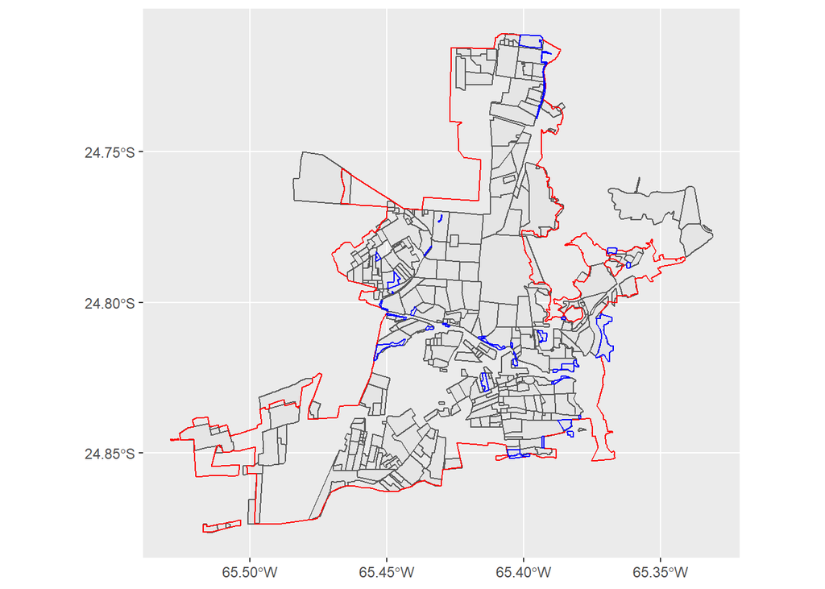

```r
ggplot()+
  geom_sf(data=barrios)+
  geom_sf(data=perimetro,color="red", fill="transparent")+
  geom_sf(data=barriospopu_salta,color="blue")
```

Nos planteamos la pregunta: ¿Cuál es la relación del deporte con los diferentes barrios de Salta? Por lo que descargamos los distintos datos de los centros deportivos de la ciudad de Salta.

```r
centros_deport <-st_read("https://idemsa.municipalidadsalta.gob.ar/descargas/Juventud%20y%20Deportes/Clubes%2C%20Federaciones%2C%20Asociaciones/clubes.geojson")
```

Procedemos a ver rápidamente la distribución de los diferentes tipos de establecimientos deportivos.

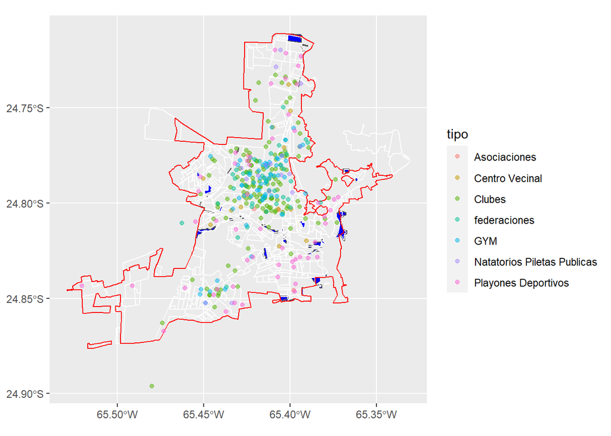

```r
ggplot()+
  geom_sf(data=barriospopu_salta,fill="blue")+
  geom_sf(data=barrios, fill="transparent", color="white")+
  geom_sf(data=perimetro,fill="transparent",color="red")+
  geom_sf(data=centros_deport,aes(color=tipo), alpha=0.5)
```

Limpiamos y ordenamos los datos del archivo geojson importado de establecimientos deportivos. Separamos los valores de longitud y latitud para tenerlos en cuenta para futuros posibles procesos.

```r
centros_deport_b <- centros_deport %>%
  mutate(lat_int = gsub( ",.*" , "", geometry),
         lon_int = gsub(".*," , "", geometry ) )
```

```r
centros_deport_b <- centros_deport_b %>%
mutate(latitude = as.numeric(str_remove(lat_int, "c\\(")),
         longitude = as.numeric(str_remove(lon_int, "\\)" )))
```

Los datos que figura sin dato, los reemplazamos por el nombre: “s/n” sin nombre.

```r
centrosdeportivos <- replace(centros_deport_b,is.na(centros_deport_b),"s/n")
```

Eliminamos algunos campos/columnas y agrupamos por los distintos tipo de establecimientos deportivos.

```r
editado<-centrosdeportivos %>%
  select( -nombre,-lat_int,-lon_int)
editado<-editado %>%
  group_by(tipo) %>%
  summarise(cantidad=n())%>%
arrange(desc(cantidad))
head(editado,7)
```

```
## Simple feature collection with 7 features and 2 fields
## Geometry type: MULTIPOINT
## Dimension:     XY
## Bounding box:  xmin: -65.52034 ymin: -24.89601 xmax: -65.3722 ymax: -24.71953
## Geodetic CRS:  WGS 84
## # A tibble: 7 x 3
##   tipo                        cantidad                                  geometry
##   <chr>                          <int>                          <MULTIPOINT [°]>
## 1 Clubes                           136 ((-65.40855 -24.7328), (-65.40263 -24.73~
## 2 GYM                               57 ((-65.42889 -24.7776), (-65.43029 -24.78~
## 3 Playones Deportivos               52 ((-65.40871 -24.71953), (-65.40251 -24.7~
## 4 federaciones                      43 ((-65.40402 -24.74976), (-65.43301 -24.7~
## 5 Natatorios Piletas Publicas       16 ((-65.40816 -24.7285), (-65.40548 -24.71~
## 6 Centro Vecinal                    15 ((-65.40094 -24.73764), (-65.39972 -24.7~
## 7 Asociaciones                       6 ((-65.42087 -24.803), (-65.40673 -24.803~
```

Unimos los datos de barrios con los centros deportivos para poder analizar la relación entre ambas bases de datos.

```r
centros_deport_geo <- centrosdeportivos %>%
    st_as_sf(coords = c("long", "lat"), crs = 4326)
class(centros_deport_geo)
```

```
## [1] "sf"         "data.frame"
```

```r
union_prueba <- st_join(centros_deport_geo, barrios)
```

Eliminamos las observaciones sin dato y volvemo a visualizar los datos.

```r
union_prueba <- union_prueba %>%
  filter(!is.na(BARRIO_N_1))
```

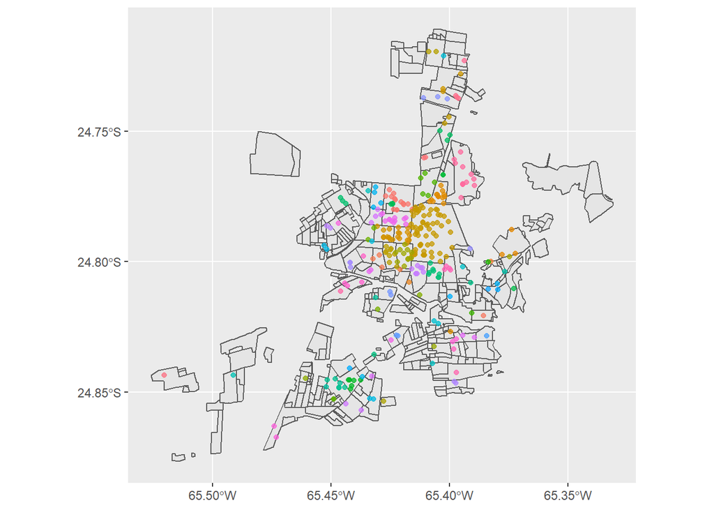

```r
ggplot()+
  geom_sf(data=barrios)+
  geom_sf(data=union_prueba, aes(color=BARRIO_N_1), alpha=0.75, show.legend = FALSE)
```

A esta base de datos de puntos de los establecimientos deportivos, le sacamos provecho, agrupando los datos por barrio para saber la cantidad total que hay por cada uno y sumamos una columna nueva extra de densidad de centros deportivos por m2 de cada barrio.

```r
union_prueba_b <- union_prueba %>%
  group_by(BARRIO_N_1) %>%
  summarise(cantidad=n(),
            densidad_depor=mean(cantidad/Shape_Area))
```

Mapeamos los nuevos datos para poder tener una previsualización de la densidad, aunque la verdadera intención es poder verla en un mapa coroplético.

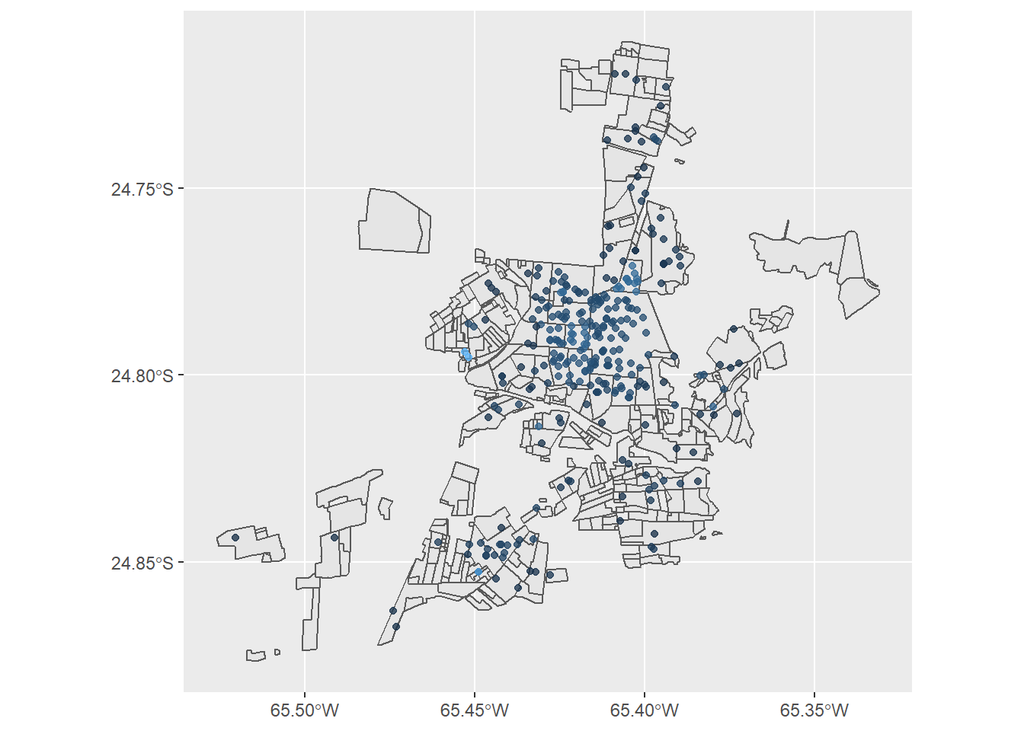

```r
ggplot()+
  geom_sf(data=barrios)+
  geom_sf(data=union_prueba_b, aes(color=densidad_depor), alpha=0.75, show.legend = FALSE)
```

Por lo que nuestro siguiente paso es pasar la nueva información a los polígonos de los barrios.

```r
union_prueba_b <- union_prueba_b %>%
  st_set_geometry(NULL)
```

```r
union_prueba_b <- union_prueba_b %>%
  arrange(desc(cantidad))
head(union_prueba_b)
```

```
## # A tibble: 6 x 3
##   BARRIO_N_1    cantidad densidad_depor
##   <chr>            <int>          <dbl>
## 1 CENTRO              63     0.0000132
## 2 20 DE FEBRERO       14     0.0000106
## 3 BELGRANO            14     0.0000240
## 4 TRES CERRITOS       12     0.00000528
## 5 CALIXTO GAUNA       11     0.0000222
## 6 CRISTINA            11     0.0000163
```

Ejecutamos un LEFT JOIN a através del nombre de los barrios y luego visualizamos los datos.

```r
barrio_b <- left_join(barrios, union_prueba_b, by="BARRIO_N_1")
```

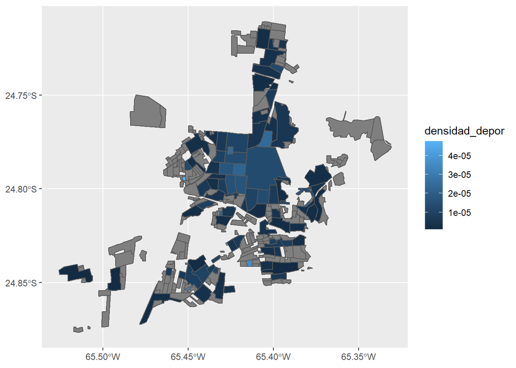

```r
ggplot()+
  geom_sf(data=barrio_b, aes(fill=densidad_depor))
```

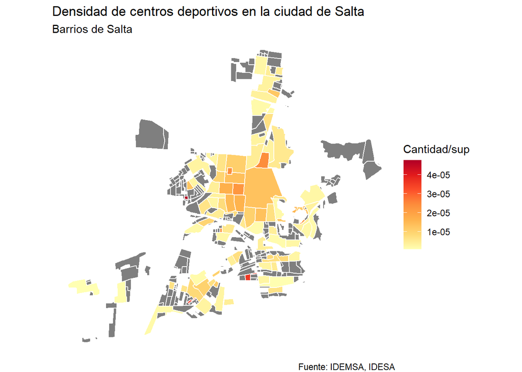

```r
ggplot()+
  geom_sf(data=barrio_b, aes(fill=densidad_depor), color="white")+
    labs(title = "Densidad de centros deportivos en la ciudad de Salta",
         subtitle = "Barrios de Salta",
         fill = "Cantidad/sup",
         caption= "Fuente: IDEMSA, IDESA ") +
  scale_fill_distiller(palette = "YlOrRd", direction = 1) +
   theme_void()
```

Buscamos un gráfico adecuado para poder ver las cantidades por cada barrio y determinar un ranking.

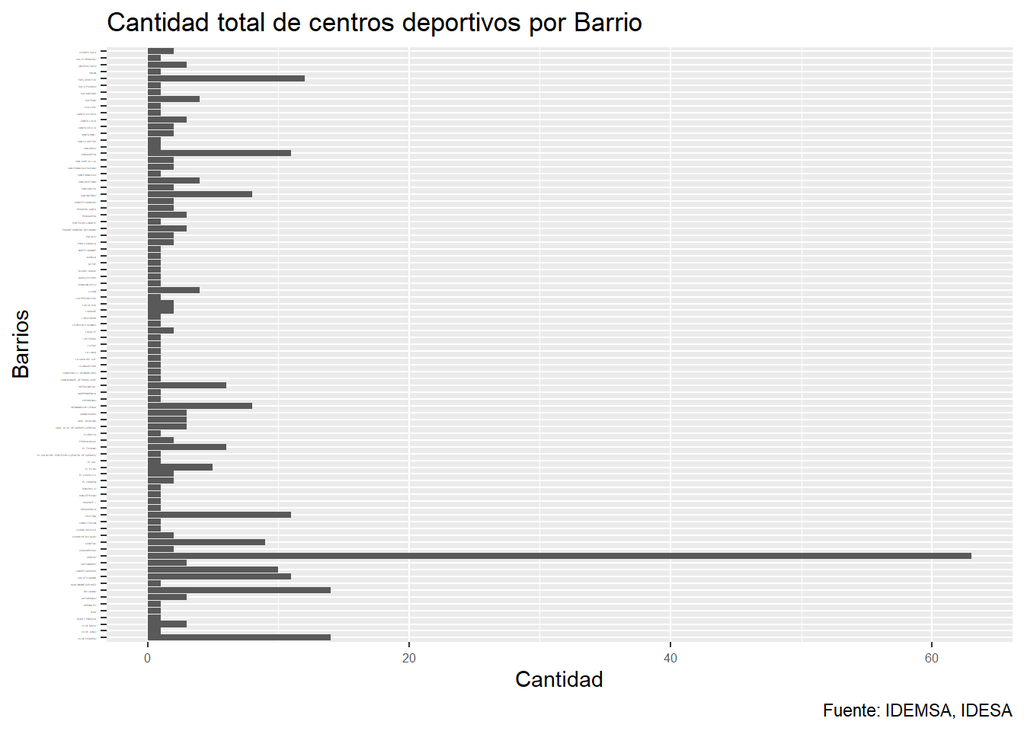

```r
ggplot(union_prueba)+
  geom_bar(aes(x=BARRIO_N_1 ))+
  coord_flip()+
  labs(title="Cantidad total de centros deportivos por Barrio",
       x="Barrios",
       y="Cantidad",
       caption="Fuente: IDEMSA, IDESA")+
  theme(legend.position="top",
        legend.direction = "horizontal",
        legend.title=element_text(size=8, face = "bold"),
        legend.text=element_text(size=8),
        axis.text.x = element_text(colour = "gray35",size = 6),
        axis.text.y = element_text(colour = "gray35",size = 1))
```

[figure not shown]

```r
ggplot()+
  geom_sf(data=barrio_b, aes(fill=cantidad), color="white")+
    labs(title = "Cantidad de colegios en la ciudad de Paris",
         subtitle = "Barrios de Paris",
         fill = "Cantidad",
         caption= "Fuente: Paris DATA") +
  scale_fill_distiller(palette = "YlGnBu", direction = 1) +
   theme_void()
```

Con los paso y el gráfico de cantidades podemos decir que los siguientes 5 barrios son los que tiene la mayor cantidad de centros deportivos. 1. **Centro** 2. **20 de Febrero** 3. **Belgrano** 4. Tres Cerritos 5. Calixto Gauna

## **BARRIOS POPULARES**

En este caso decidimos ver la relación entre los distito centros deportivos y los barrio catalogados por el RENABAP.Por lo que unimos las bases de datos.

```r
centros_deport_geo <- st_join(centros_deport_geo, barriospopu_salta)
```

## **VISUALIZACIÓN DINÁMICA**

Descargamos una base de mapa para cambiar la visualización de nuestra información. Usamos la información de OSM, Open Street Map.

```r
library(ggmap)
library(osmdata)
bbox_salta <- getbb(" Salta, Salta, Argentina")
```

```r
mapa_salta <- get_stamenmap(bbox=bbox_salta,
                              maptype="toner-lite",
                              zoom=14)
```

```
## 72 tiles needed, this may take a while (try a smaller zoom).
```

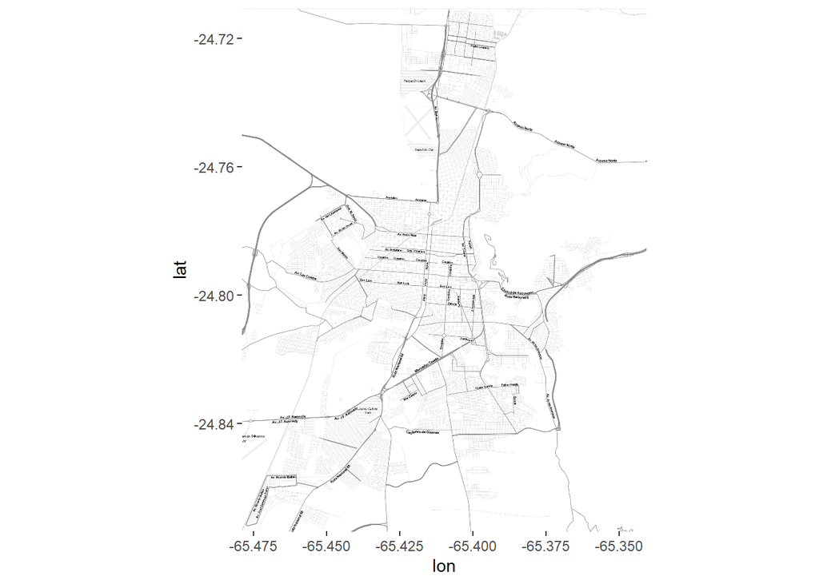

```r
ggmap(mapa_salta)
```

```r
poligono_salta <- getbb(" Salta, Salta, Argentina",
                            format_out = "sf_polygon")
```

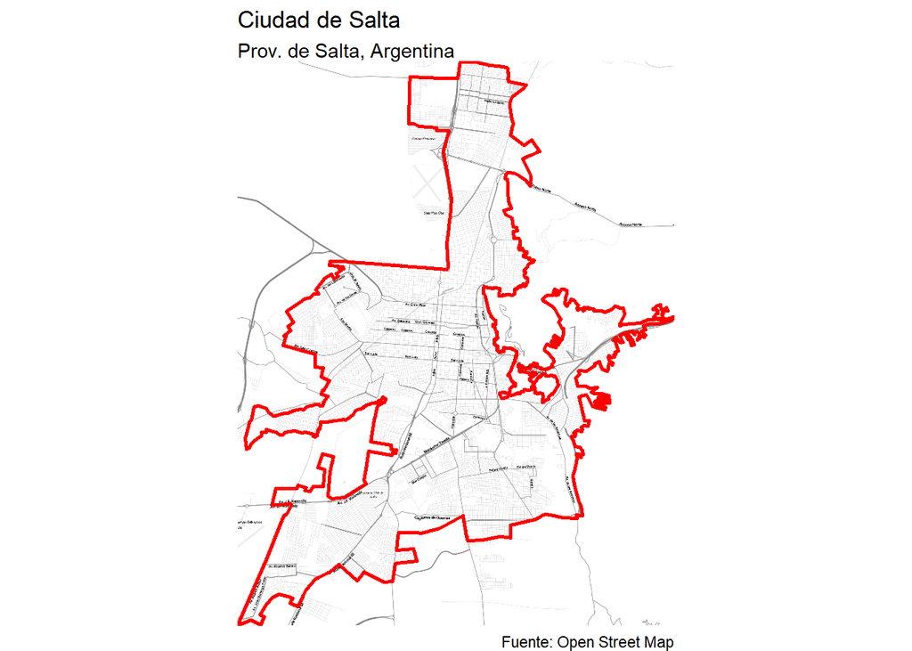

```r
ggmap(mapa_salta)+
  geom_sf(data=poligono_salta, fill=NA, color="red", size=1, inherit.aes = FALSE)+
  labs(title="Ciudad de Salta",
       subtitle="Prov. de Salta, Argentina",
       caption="Fuente: Open Street Map")+
  theme_void()
```

Exploramos otro tipo de visualización con **LEAFLET** y probamos que funcione bien la base principal.

```r
library(leaflet)
```

```r
leaflet() %>%
  addTiles() %>%
  addPolygons(data=poligono_salta)
```

[interactive chart not shown]

Limpiamos los dato de la base de datos de los centros deportivos para poder mapearlos con leaflet.

```r
centros_deport_geo_b <- centros_deport_geo %>%
          filter(!is.na(Name), !is.na(tipo)) %>%
  mutate_if(is.character, iconv, from="UTF-8", to="latin1" )
```

Cargamos los puntos de los centros deportivos y editamos su visualización.

```r
leaflet() %>%
   addProviderTiles(providers$CartoDB.Positron) %>%
  addCircleMarkers(data=union_prueba,
             popup=paste("Nombre:",union_prueba$Name, "<br>",
                           "Tipo:", union_prueba$tipo))%>%
  addPolygons(data=barriospopu_salta, color="blue")%>%
addPolygons(data=poligono_salta, color = "red")
```

[interactive chart not shown]

```r
leaflet() %>%
   addProviderTiles(providers$CartoDB.Positron) %>%
  addCircleMarkers(data=union_prueba,
             popup=paste("Nombre:",union_prueba$Name, "<br>",
                           "Tipo:", union_prueba$tipo),
             color = ~colorFactor(palette=c("seagreen4","deeppink","deepskyblue","darkolivegreen","darkgoldenrod1","cyan","coral"),
                                        levels=union_prueba$tipo)(tipo))%>%
  addPolygons(data=barriospopu_salta, color="red")%>%
addPolygons(data=poligono_salta)
```

[interactive chart not shown]

Con este último mapa podemos ver todos los puntos de los centros deportivos con un color diferente por cada tipo de establecimiento, con sus etiquetas correspondientes. También tenemos los bordes de la ciudad de Salta y de los barrios populares del RENABAP por lo que al tener la posibilidad de hacer zoom podemos ver la relación estos puntos con los diferente barrios.

## **CONCLUSIONES**

Podemos detectar algunos detalles:

-En cuanto a la disponibilidad de información de esta ciudad se complicó conseguir la información deseada. -Hubiera sido interesante poder cruzar los datos entre polígonos, entre los distintos barrios para saber cuáles son los que tienen relación con barrios del RENABAP o hacer un buffer por cada centroide de los barrios RENABAP y ver cuantos establecimientos se encuentran en un radio de 10 cuadras como mínimo.